# Association rule learning

Association rule learning is a rule-based machine learning method for discovering interesting relations between variables in large databases. It is intended to identify strong rules discovered in databases using some measures of interestingness.

reference:https://en.wikipedia.org/wiki/Association_rule_learning

# ARM (Association Rule Mining)

ARM is one of the methods of ARL because its rule is an IF/THEN statement, hence the name. In this project we will use this method to find the relationship between our tweets and individual words.

```
              rhs           lhs  supp      conf  supp x conf       lift
0      [Although]        [Dojo]  0.09  1.000000     0.090000  11.111111
1          [Dojo]    [Although]  0.09  1.000000     0.090000  11.111111
2      [Although]        [Mars]  0.09  1.000000     0.090000  10.526316
3          [Mars]    [Although]  0.09  0.947368     0.085263  10.526316
4      [Although]      [energy]  0.09  1.000000     0.090000   1.212121
..            ...           ...   ...       ...          ...        ...
856  [vulnerable]        [text]  0.02  1.000000     0.020000  50.000000
857        [text]     [warning]  0.02  1.000000     0.020000  50.000000
858     [warning]        [text]  0.02  1.000000     0.020000  50.000000
859  [vulnerable]     [warning]  0.02  1.000000     0.020000  50.000000
860     [warning]  [vulnerable]  0.02  1.000000     0.020000  50.000000

[861 rows x 6 columns]
```

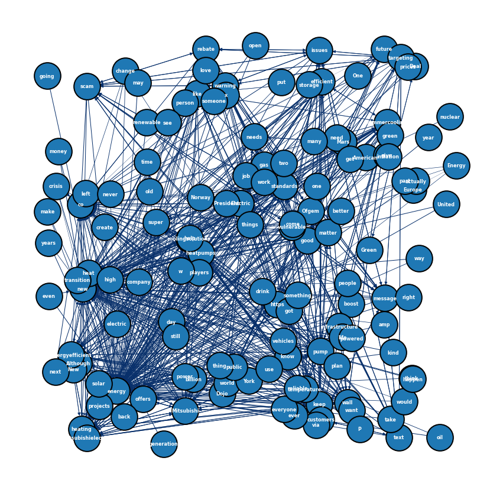

```python
import pandas as pd
from nltk.tokenize import word_tokenize
from apyori import apriori
import networkx as nx
from nltk.corpus import stopwords
import matplotlib.pyplot as plt
# read the data
import pandas as pd
from nltk.tokenize import word_tokenize
from apyori import apriori
import networkx as nx
from nltk.corpus import stopwords
import matplotlib.pyplot as plt
# read the data
twitter=pd.read_csv("twitter_data_clean.csv")


twitter["text"]=twitter["text"].apply(word_tokenize)
twitter=twitter["text"].apply(drop_stop)


def reformat_results(results):

    keep =[]
    for i in range(0, len(results)):
        for j in range(0, len(list(results[i]))):
            if (j>1):
                for k in range(0, len(list(results[i][j]))):
                    if (len(results[i][j][k][0]) != 0):
                        rhs = list(results[i][j][k][0])
                        lhs = list(results[i][j][k][1])
                        conf = float(results[i][j][k][2])
                        lift = float(results[i][j][k][3])
                        keep.append([rhs,lhs,supp,conf,supp*conf,lift])
            if (j==1):
                supp = results[i][j]

    return pd.DataFrame(keep, columns =["rhs","lhs","supp","conf","supp x conf","lift"])

def convert_to_network(df):
    print(df)
    G = nx.DiGraph()
    for row in df.iterrows():
        lhs="_".join(row[1][0])
        rhs="_".join(row[1][1])
        conf=row[1][3];
        if(lhs not in G.nodes):
            G.add_node(lhs)
        if(rhs not in G.nodes):
            G.add_node(rhs)

        edge=(lhs,rhs)
        if edge not in G.edges:
            G.add_edge(lhs, rhs, weight=conf)
    return G

def plot_network(G):
    pos=nx.random_layout(G)
    fig, ax = plt.subplots()
    fig.set_size_inches(15, 15)
    weights_e   = [G[u][v]['weight'] for u,v in G.edges()]
    cmap=plt.cm.get_cmap('Blues')
    colors_e    = [cmap(G[u][v]['weight']*10) for u,v in G.edges()]
    nx.draw(
    G,
    edgecolors="black",
    edge_color=colors_e,
    node_size=2000,
    linewidths=2,
    font_size=8,
    font_color="white",
    font_weight="bold",
    width=weights_e,
    with_labels=True,
    pos=pos,
    ax=ax
    )
    plt.show()


results = list(apriori(twitter, min_support=0.02, min_confidence=0.2, min_length=3, max_length=2))
pd_results = reformat_results(results)
result = convert_to_network(pd_results)
plot_network(result)
```

# Result

The density of the lines between the different words in the image above makes it clear which words are more relevant to each other and, combined with the graph as a whole, which words are most relevant to the topic in tweets containing "new energy". This is the final presentation of the so-called regular algorithm.

# Conclusion

ARM has a certain effect on our project, because it can see the correlation between words. For our first ten questions, it can well see which words in tweets about new energy are related, so as to analyze the most important information related to this topic. Generally speaking, it is a good model, but we need to judge by the correlation between different words, which is too tedious, so it is better to use SVM.